# Compulsory exercise 2

Truls Carlson and Markus Woxholt

2025-08-15

```r
# Load necessary packages
library(dplyr)
library(caret)
library(ggmap)
library(randomForest)
library(sp)
library(leaflet)

# Load data
Berlin <- read.csv("~/Documents/Studier/Statlaer/navn/archive/berlin_weekends_neighborhoods.csv")
#Berlin <- read.csv("~/Documents/V25/Statlær/Comp2/archive/berlin_weekends_neighborhoods.csv")
```

# Abstract

The goal of this project is to predict the neighborhood of an AirBnB listing in Berlin based on key features such as price, room type, capacity, distance to public transport, and various location-based indices. By framing this as a classification problem, we aim to identify which factors are most influential in determining an AirBnB’s location within the city. This has potential implications not only for real estate and tourism platforms, but also for understanding socioeconomic patterns across urban neighborhoods.

# Introduction

The general idea of this project is to use the provided data set berlin_weeknds.csv to predict the neighborhood of an AirBnB apartment based on the variables given in the dataset. For a given AirBnB, the datasets includes parameters such as price per night, room type, distance to metro and distance to city centre. The goal of this work is to see if there are local patterns within the rental market in Berlin. The data sets are retrieved from the Kaggle data science community and are a part of a bigger set which contains listings of AirBnBs from several of the most popular European tourist cities.

In the project we wish to investigate which predictors are predominant when differencing neighborhoods in a big European city. Berlin’s variation in urban environments due to the historic separation between eastern and western neighborhoods, its great geographic extent and socioeconomic diversity makes it an interesting case for our investigations.

To answer these questions, our goal is to find a method that to the greatest extent classifies the apartments correctly to their respectful neighborhood. As we are considering a data set which is not too big we will not put much emphasis on the model’s computational cost. It is however important that it clearly describes what predictors are predominant when classifying.

We hope that the results from this project can give insights in the housing differences of the neighborhoods in Berlin, and in that sense might be of use for anyone interested in socioeconomic differences and/or urban planning in European cities.

We start our descriptive analysis by mapping the provided AirBnBs onto the Berlin map, just to get a visual overview of the data.

[figure not shown]

Our hypothesis is that price of the apartment and distance to city centre are important predictors dividing the neighborhoods. We therefore take a look at those predictors.

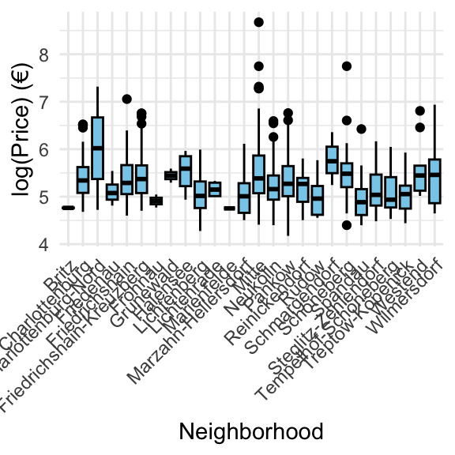

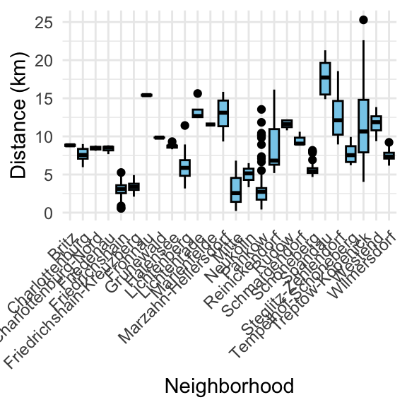

Berlin housing prices and distance to city centre by neighborhood

We see that the price difference between the neighborhood is actually not that big, even when considering a logaritmic scale, but the difference within each neighborhood is substantial. Some neighborhoods does, on the other hand, have a much wider distribution, than others. We have observed that some neighbourhoods have few listings, which morelikely gives a narrow distribution. We observe however that the distance from city centre is a much more diverse predictor, indicating our presumption that this might be a good predictor.

We chose Berlin for our project partly due to its historic partition. We are suspecting socioeconomic differences between the East and the West, affecting the AirBnB market, so we take a look at the price and attractiveness index difference between the eastern and western neighborhoods.

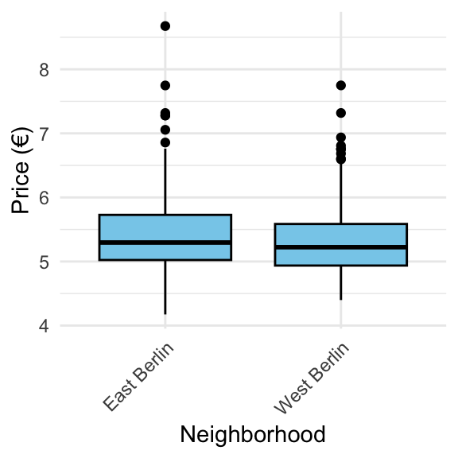

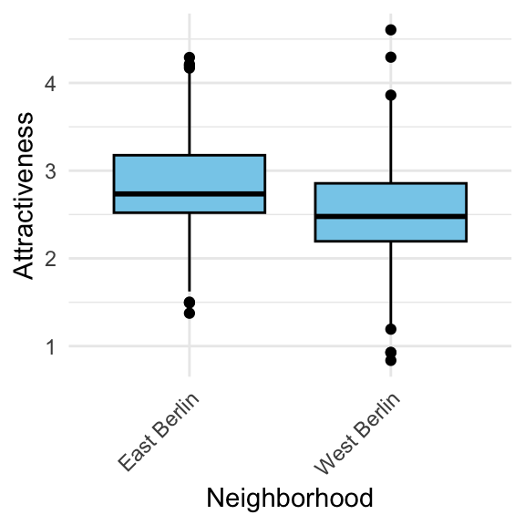

Berlin housing prices and attractiveness by region

Our suspicions on big differences in price and attractiveness bewteen East and West, Berlin seems however to be incorrect. If something East Berlin is more expensive and attractive. The attractiveness index might depend more on neigborhood than the east-west divide.

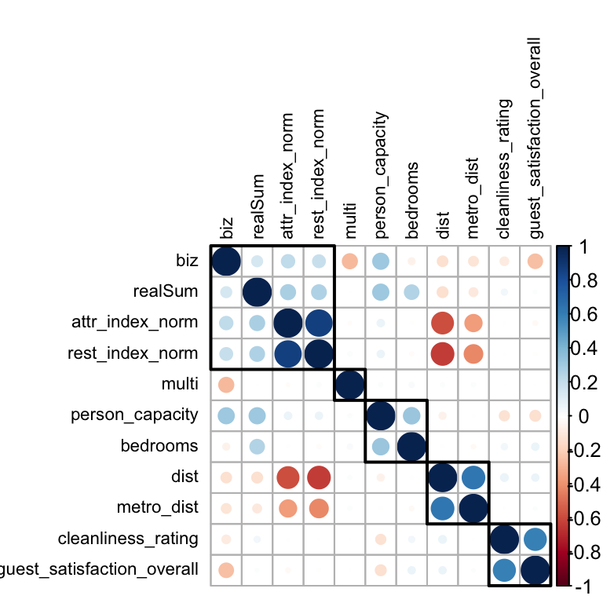

We observe that several of our predictors are correlated. We should be aware of this when choosing methods. Some methods are more sensitive to correlation than others.

# Methods

In this section, we describe the methods used in detail. We begin by explaining the preprocessing steps applied to the dataset, followed by a description of the classification models used to solve the problem.

## Setup

First, we classified the listings into neighborhoods based on their longitude and latitude with a Python-script. The script uses the package which lets you use data from and fetch boundaries based on administrative levels (neighborhoods). With this we were able to assign a point (longitude, latitude) to a Berlin neighborhood.

The resulting variable consists of 26 distinct classes and serves as the response variable in our classification problem. As longitude and latitude were only used to derive the class labels, they were removed from the feature set to avoid redundancy and to encourage more meaningful predictions.

This gives us a new qualitative variable with 26 different classes in contrast to the quantitative variables longitude and latitude. With this it is easy to formulate a classification problem. It is worth mentioning that we removed the longitude and latitude features for more meaningful predictions. To ensure more robust and reliable classification, we excluded listings from neighborhoods with fewer than five observations. Rare categories can cause issues during model training and evaluation, particularly in cross-validation, where some folds may contain no examples of these rare neighborhoods.

All numerical features were standardized using the mean and standard deviation of the training set. This scaling was applied to both the training and test data to prevent data leakage, i.e. that the test_data “sees” test data statistics.

## Feature engineering

```r
# Add new features
# First we copy the unscaled train_data into new variables
# Then we scale the new datasets

train_data_new <- train_data #
test_data_new <- test_data
train_data_new$access_score = log(train_data_new$dist) + log(train_data_new$metro_dist)
test_data_new$access_score = log(test_data_new$dist) + log(test_data_new$metro_dist)
train_data_new$attr_rest = log(train_data_new$attr_index) + log(train_data_new$rest_index)
test_data_new$attr_rest = log(test_data_new$attr_index) + log(test_data_new$rest_index)

num_vars_new = sapply(train_data_new, is.numeric)
# Find the mean and the standard deviation for the train data
train_means_new = sapply(train_data_new[num_vars_new], mean)
train_sds_new = sapply(train_data_new[num_vars_new], sd)
train_data_new[num_vars_new] = scale(train_data_new[num_vars_new], center = train_means_new, scale = train_sds_new)
test_data_new[num_vars_new] = scale(test_data_new[num_vars_new], center = train_means_new, scale = train_sds_new)
```

## Multinomial Logistic Regression

We use (MLR) to classify listings into one of 26 Berlin neighborhoods. Since the response variable is categorical with more than two classes, this method is well-suited to the task, as it handles categorical factors directly. It models the probabilities of each neighborhood given the predictors and allows for a clear interpretation of which features are important for the classification.

Given a feature vector $X$ of the variables in the dataset, and a qualitative response $Y \in N$ where $N$ represents the set of neighborhoods in Berlin, we wish to find a function $C(X)$ that takes the feature vector $X$ as input and predicts the corresponding neighborhood:
$$\begin{equation}
C(X) = Y, \hspace{0.2cm} Y \in N
\end{equation}$$

Since there are 26 different neighborhoods in Berlin, we are dealing with a classification problem with more than two classes, i.e., $|N| > 2$. A suitable method for this is Multinomial Logistic Regression, an extension of binary logistic regression that can handle multiple outcome categories. It estimates the probabilities of each possible class $Y = k$ given $X = x$ ().

First we select a single class to serve as the baseline, and then we model the log odds of the remaining classes relative to that baseline.

In our implementation, we use the function from the package in R. By default, this function treats the first level of the response variable as the baseline class as described in the package manual (@multinom_ref).

### Improve the model

To improve the multionomial logistic regression model we first try to add the new features as described in section @feat, before we perform subset selection.

#### Subset selection

We want to identify a subset of the $p$ predictors that contribute the most to determining the neighborhood of an AirBnB listing. Ideally we would try every possible combination of the $p$ predictors using . However, this approach has computational limitations, as the number of different models to consider grows exponentially — in general, $2^p$ possible models (). Instead we use more efficient methods. We consider the methods: and . We also tried bidirectional stepwise selection, but it produced the same model and accuracy as backward selection in our case, so we omit it from the discussion.

Forward stepwise selection explores a much more restricted set of models. This makes it scalable to high-dimensional datasets and computationally efficient. The method begins with a -model without any predictors, and then step-by-step adds the predictor that improved the model the most. A drawback with this method, is that it is not guaranteed to find the best model ().

Backward stepwise selection, in contrast to forward selection, begins with the full model containing all $p$ predictors, and iteratively removes predictors that contribute the least to model performance (). This method is only applicable when the number of observations $n$ is larger than the number of predictors $p$, which is the case in our dataset.

## Random Forest

The random forest method is a tree-based method which consists of building a number of of decision trees on bootstrapped training samples. The general idea of three-based methods is to segment simple regions for then to use the mean response for the training observation in the region it belongs. Tree-based methods can be used for both prediction and classification. As we are considering a classification problem, our random forest model will build on classification trees which predicts that each observation belongs to the most commonly occuring class in the region.

The advantage of the random forest over a bagged method, is that at each split in a tree it chooses a random sample of $m$ predictors from the full set of $p$ predictors. Avoiding that the same predictors are considered at all splits uncorrelates the trees and lowers the variance as very strong predictors are partially excluded at each step. $m \approx \sqrt p$ is a normal choice for the random forest method.

In the context of our dataset, the random forest method peaked our interest as it can handle both quantitative and categorical predictors, which made it a better choice than for instance a KNN-method, which we also considered. The strength of the random forest method is that it easily handles large amount of predictors and that it does not easily overfit to the data, both due to the random selection of predictors at each split (). Although our data set only contains a moderate amount of data points, we are suspecting on the basis of our descriptive analysis that we have some very strong indicators in our data set. Random forest could provide good results, by avoiding overfitting as it partially exclude the strongest predictors from many of the splits.

The weaknesses of random forests, compared to other methods, is that it is computationally expensive and less interpretable than for instance a single tree. Our data set, however, is as previously mentioned moderately big, which still could make it suitable for the random forest method. The interpretability of the model can, in our case, be a disadvantage.

There are three hyperparameters available for tuning in the random forest model; the number of trees grown, the size $m$ of predictors used in the fitting and the node sizes of the trees. In this project we will tune these hyperparameters using the Out-of-Bag (OOB) error estimate and 5-fold cross validation. To tune the number of trees, we will search for where the OOB error estimate for each tree stabilizes. To tune the parameter $m$, we use the 5-fold cross validation via the train()-function from the caret-library. This function compares the training accuracy of a random forest model for different values of $m$. We could also estimate $m$ using the OOB error estimate, but according to \cite(janitza2018) it is questionable whether this is a good approach for a classification problem.

## Evaluation of performance

As we are considering a multidimensional classification problem, we will evaluate the performance of our chosen models using the classification accuracy.

## Scaling

We scale both the training data and the test data with the mean and standard deviation from the training data. This prevents data leakage.

# Results

## Multinomial Logistic Regression

Here we present the results of the multinomial logistic regression without the added features, added features and finally forward and backward stepwise also with the added features.

### Without feature engineering

```r
library(nnet) # Package which includes the mulitnom() function

# Fit model
model = multinom(Neighborhood~., data = train_data_scale)

# Prediction
prediction = predict(model, newdata = test_data_scale)

# Make confusion matrix for easy analysis of the results
multinom_cm = confusionMatrix(prediction, test_data$Neighborhood)
```

```r
multinom_cm$overall["Accuracy"]
```

```
##  Accuracy
## 0.5734463
```

### With feature engineering:

```r
model_new = multinom(Neighborhood~., data = train_data_new)
prediction = predict(model_new, newdata = test_data_new)

# Make confusion matrix for easy analysis of the results
new_features_cm = confusionMatrix(prediction, test_data_new$Neighborhood)
```

```r
new_features_cm$overall["Accuracy"]
```

```
##  Accuracy
## 0.6412429
```

### With forward stepwise

```r
## FORWARD STEPWISE
# Define model containing zero predictors
zero <- multinom(Neighborhood ~ 1, data=train_data_new)
# Define model containing all predictors
all = multinom(Neighborhood~., data = train_data_new)

forward <- step(zero,
                  scope=formula(all),
                  direction = "forward", trace = 0)

for_vars <- attr(terms(forward), "term.labels")
for_pred = predict(forward, newdata = test_data_new)
for_cm = confusionMatrix(for_pred, test_data_new$Neighborhood)
```

```r
for_cm$overall["Accuracy"]
```

```
##  Accuracy
## 0.7062147
```

### With backward stepwise

```r
# BACKWARD STEPWISE
set.seed(1)
backward <- step(all,
                   direction = "backward", trace = 0)

back_vars <- attr(terms(backward), "term.labels")
back_pred = predict(backward, newdata = test_data_new)
back_cm = confusionMatrix(back_pred, test_data_new$Neighborhood)
```

```r
back_cm$overall["Accuracy"]
```

```
##  Accuracy
## 0.7231638
```

We observe that the backward stepwise acchieves the highest accuracy. In general we observe that the stepwise selection improves the model, this is because it improves generalization by avoiding overfitting. When including too many predictors the model can tend to get overfitted.

### Important features

To get an insight in the most important features to predict the Neighborhood of a listing, we can use the method on the model obtained in @multibby,

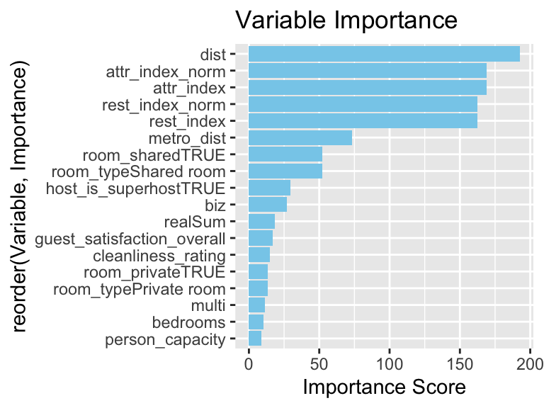

With the stepwise selection methods described in @subset we identified the features contributing the most to predicting the neighborhood of an AirBnB listing. The figure below shows the included predictors by the two different approaches.

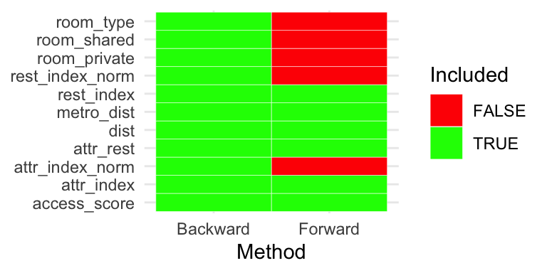

Included predictors by stepwise method

```r
all_vars <- sort(unique(c(for_vars, back_vars)))

model_matrix <- data.frame(
  Variable = all_vars,
  Backward = all_vars %in% back_vars,
  Forward = all_vars %in% for_vars
)

library(tidyr)
library(ggplot2)

model_long <- pivot_longer(model_matrix, -Variable, names_to = "Method", values_to = "Included")

ggplot(model_long, aes(x = Method, y = Variable, fill = Included)) +
  geom_tile(color = "white") +
  scale_fill_manual(values = c("TRUE" = "green", "FALSE" = "red")) +
  theme_minimal() +
  theme(axis.title.y = element_blank())
```

## Random forest

We start our analysis of the random forest model we create a frame of reference fitting a random forest method using a popular choice of hyperparameters. We used the default hyperparameters of the randomForest()-function, $m=\sqrt p$ and number of trees $ntree=500$. Considering this untuned model we take a look at figure @default_forest assessing the most influential predictors in the random forest model.

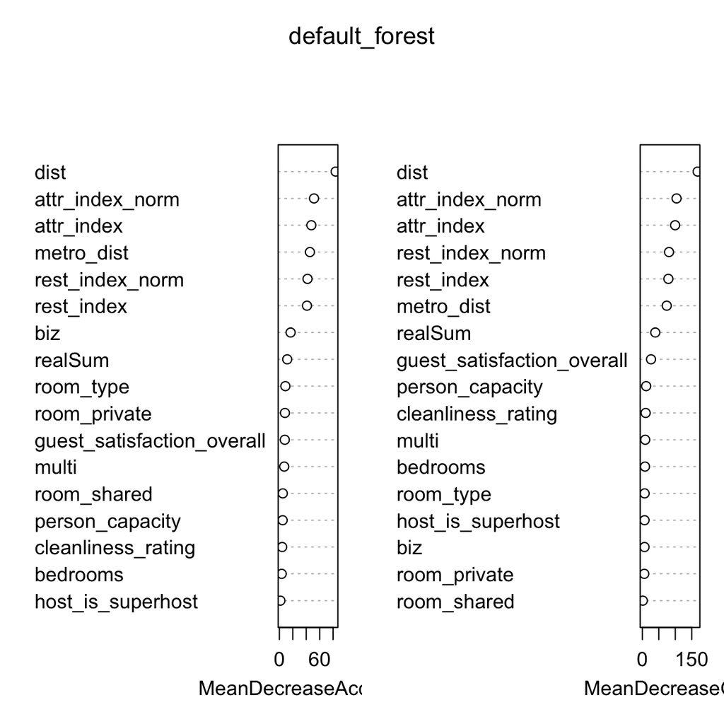

Variable importance plot, default forest.

Again, we see that the distance to city centre variable is by far the most important. In contrast to our prior beliefs, price of the apartment is only the eight most important variable. Other important variables in the random forest model are attractiveness index, distance to the metro and the restaurant index.

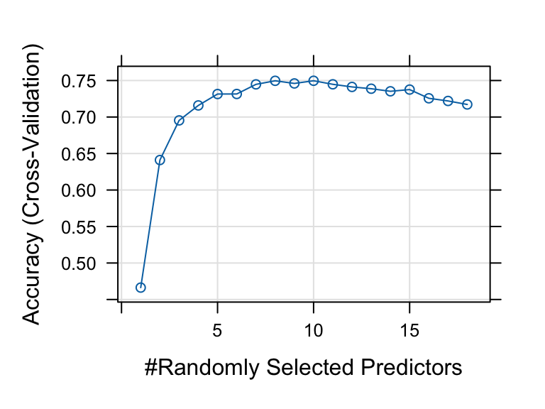

Cross validated accuracy for different $m$.

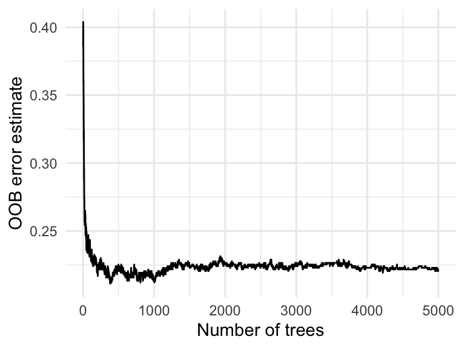

OOB error estimate

A weakness in our tuning method is that we assume that $m$ and number of trees are independent parameters. However, as we grow a large number of trees in our random forest, the ensemble averaging nature of the model lowers the importance of interactions between the hyperparameters. As we have seen from figure $\ref{fig:plot_OOB}$, the OOB error estimate comes to rest which indicates that increasing the amount of trees beyond this point will not increase accuracy independently of $m$.

Comparison of Random Forest Models

[output not shown]

## Mean CV accuracy

To compare our two models we conduct a k-fold cross validation. As previously discussed, a weakness with our data is that some Neighborhood categories have few data points. Therefore, when seperating the training set into folds we risk having categories left out of one or more folds, which make the random forest model break down (at least within the framework of rStudio). We therefore conducted a k-fold cross validation using stratified folds, making sure that every category was represented at least once in each fold. We also adjusted the number of folds to the rarest category.

```
##
## Mean accuracy random forest: 0.7349
```

```
##
## Mean accuracy random forest with new features: 0.7325
```

```
##
## Mean accuracy multinomial regression with new features: 0.6132
```

```
##
## Mean accuracy forward with new features: 0.7
```

```
##
## Mean accuracy backward with new features: 0.6916
```

We observe that the random forest model has the highest accuracy of the two.

# Summary

In this project we sought to classify AirBnB apartments from the berlin_weekends.csv data set. Our hypothesis was that the price differences and distance to the city centre would be the dominant factors of an AirBnB location. We were also suspicious that the old East/West-divide of Berlin would be visible, especially when considering price and attractiveness of the apartment. We were right in our presumtion that the distance to the city centre was the dominant predictor, however, we saw that the price played a much more insignificant role in determining the classification of an apartment to its respective neighborhood. The east/west divide was almost not visible in our findings at all. However, AirBnBs are more used for vacation purposes than long-time rentals, which might explain the lack of price difference between East Berlin, which is in general considered more socioeconomically challenged than its western counterpart.